# P8451_HW12_ML

Ruixi Li

2024-04-14

### Step 1: Load Packages

We will use the matchit package for matching by propensity score and the randomforest within the caret package to generate the propensity score.

```r
library(MatchIt)
library(randomForest)
library(caret)
library(tidyverse)
```

### Step 2: Read-in and clean data

For random forest, cannot have any missing data. For illustration purposes, we will conduct a complete-case analysis.

Note that missing data have been denoted by a ‘.’. So we need to change that to NA and then restrict to complete cases. Also need to convert numeric data to factor where appropriate.

```r
nmes_data <- read.delim("nmes_data.txt")

#Restrict to only needed variables
keep.var<-c("LASTAGE", "MALE", "RACE3", "eversmk", "lc5", "beltuse", "educate", "marital", "SREGION", "POVSTALB")
nmes.data<-nmes_data[,keep.var]

#Inspect data summaries
str(nmes.data)
```

```
## 'data.frame':    13648 obs. of  10 variables:
##  $ LASTAGE : int  80 78 80 71 69 70 60 82 58 46 ...
##  $ MALE    : int  0 0 1 1 0 0 0 0 1 0 ...
##  $ RACE3   : int  3 3 3 3 3 3 3 3 3 3 ...
##  $ eversmk : chr  "0" "." "1" "1" ...
##  $ lc5     : int  0 0 0 0 0 0 0 0 0 0 ...
##  $ beltuse : chr  "3" "3" "1" "3" ...
##  $ educate : int  4 3 3 3 3 1 2 3 1 1 ...
##  $ marital : chr  "2" "2" "3" "1" ...
##  $ SREGION : int  1 1 1 1 1 1 1 1 1 1 ...
##  $ POVSTALB: chr  "1" "4" "3" "5" ...
```

```r
#Recode missings
nmes.data[nmes.data=="."]<-NA

#Change variable types where appropriate
nmes.data$MALE <- as.factor(nmes.data$MALE)
nmes.data$educate <- as.factor(nmes.data$educate)
nmes.data$RACE3 <- as.factor(nmes.data$RACE3)
nmes.data$eversmk<-as.factor(nmes.data$eversmk)
nmes.data$SREGION <- as.factor(nmes.data$SREGION)
nmes.data$lc5<-as.factor(nmes.data$lc5)
nmes.data$beltuse<-as.factor(nmes.data$beltuse)
nmes.data$marital<-as.factor(nmes.data$marital)

nmes.data$POVSTALB<-factor(nmes.data$POVSTALB, order=TRUE)

nmesdata<-na.omit(nmes.data)
```

### Step 3: Estimate the Propensity Score using Elastic Net

I’m automating the tuning using both alpha and lambda.

```r
set.seed(123)
control = trainControl(method = "repeatedcv",
                      number = 10,
                      repeats = 5,
                      selectionFunction = "best")
set.seed(123)

# Model building
ps.en<- train(
                  eversmk ~LASTAGE + MALE + educate + beltuse + POVSTALB + marital + RACE3 + SREGION,
                  data=nmesdata,
                 method="glmnet",
                 metric="Accuracy",
                 importance=TRUE,
                 trControl =  control,
                 preProc = c("center", "scale"),
                 tuneGrid = expand.grid(alpha = seq(0, 1, length = 20),
                                         lambda = exp(seq(3, -3, length = 100)))
                )

#Print the values of alpha and lambda that gave best prediction
ps.en$bestTune
```

```
##   alpha     lambda
## 1     0 0.04978707
```

```r
# Model coefficients
coef(ps.en$finalModel, ps.en$bestTune$lambda)
```

```
## 21 x 1 sparse Matrix of class "dgCMatrix"
##                        s1
## (Intercept)  0.2903969393
## LASTAGE     -0.1257137010
## MALE1        0.4795987269
## educate2     0.0821795278
## educate3     0.1289772051
## educate4     0.0142627475
## beltuse2    -0.0121796361
## beltuse3    -0.1009653036
## POVSTALB.L  -0.0257472071
## POVSTALB.Q  -0.0006140757
## POVSTALB.C  -0.0202052080
## POVSTALB^4   0.0223409554
## marital2    -0.0497152242
## marital3     0.1230805920
## marital4     0.0395146671
## marital5    -0.0588195661
## RACE32       0.0296493517
## RACE33       0.1179148398
## SREGION2    -0.0492735351
## SREGION3    -0.0811187387
## SREGION4    -0.0280853493
```

```r
# Predictions for models
prop.score.en = predict(ps.en, nmesdata, type="prob")
nmesdata$PS.EN <- prop.score.en[,2]

##Using optimal values from tuning above, I'm creating my final model within the actual random forest package. ##Exercise: How would you replicate this using just the caret package?

set.seed(123)
ps.model.rf<-randomForest(eversmk~LASTAGE + MALE + educate + beltuse + POVSTALB + marital + RACE3 + SREGION,
                    data=nmesdata, mtry=3, ntree=500)

#Append predicted probabilities onto original dataset
ps.rf<-ps.model.rf$votes
nmesdata$PS.RF<-ps.rf[,2]



ps.model.logit <- glm(eversmk ~ LASTAGE + MALE + educate + beltuse + POVSTALB + marital + RACE3 + SREGION,
                      data=nmesdata,
                      family=binomial(link="logit"))
summary(ps.model.logit)
```

```
##
## Call:
## glm(formula = eversmk ~ LASTAGE + MALE + educate + beltuse +
##     POVSTALB + marital + RACE3 + SREGION, family = binomial(link = "logit"),
##     data = nmesdata)
##
## Coefficients:
##              Estimate Std. Error z value Pr(>|z|)
## (Intercept)  0.020018   0.148777   0.135 0.892966
## LASTAGE     -0.013954   0.001776  -7.855 3.99e-15 ***
## MALE1        1.243409   0.043340  28.689  < 2e-16 ***
## educate2     0.488464   0.075457   6.473 9.58e-11 ***
## educate3     0.512041   0.063243   8.096 5.66e-16 ***
## educate4     0.288245   0.076641   3.761 0.000169 ***
## beltuse2    -0.072393   0.060908  -1.189 0.234608
## beltuse3    -0.234666   0.050383  -4.658 3.20e-06 ***
## POVSTALB.L  -0.084721   0.059652  -1.420 0.155529
## POVSTALB.Q   0.019649   0.053149   0.370 0.711610
## POVSTALB.C  -0.059725   0.063476  -0.941 0.346746
## POVSTALB^4   0.086412   0.059262   1.458 0.144801
## marital2    -0.043881   0.060417  -0.726 0.467657
## marital3     0.576635   0.075572   7.630 2.34e-14 ***
## marital4     0.337629   0.133302   2.533 0.011315 *
## marital5    -0.319467   0.093215  -3.427 0.000610 ***
## RACE32       0.334378   0.096055   3.481 0.000499 ***
## RACE33       0.585721   0.086275   6.789 1.13e-11 ***
## SREGION2    -0.230836   0.060626  -3.808 0.000140 ***
## SREGION3    -0.280376   0.056489  -4.963 6.93e-07 ***
## SREGION4    -0.139669   0.065546  -2.131 0.033101 *
## ---
## Signif. codes:  0 '***' 0.001 '**' 0.01 '*' 0.05 '.' 0.1 ' ' 1
##
## (Dispersion parameter for binomial family taken to be 1)
##
##     Null deviance: 15857  on 11586  degrees of freedom
## Residual deviance: 14565  on 11566  degrees of freedom
## AIC: 14607
##
## Number of Fisher Scoring iterations: 4
```

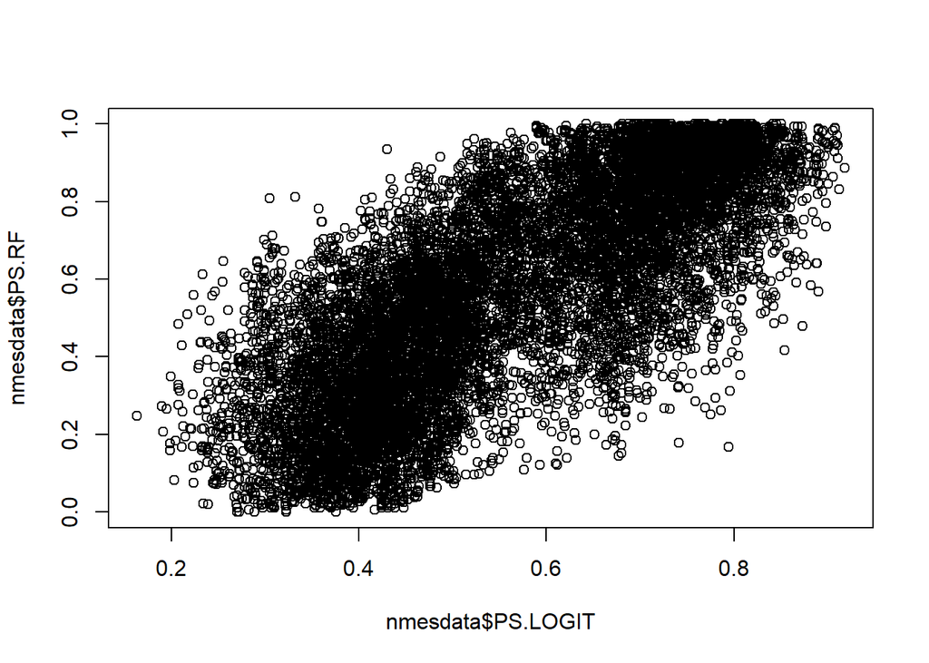

```r
# estimates odds of eversmoke, then convert to probability (aka the propensity score)
  prop.score <- (predict(ps.model.logit, nmesdata, type="response"))
  nmesdata$PS.LOGIT <- prop.score # the logistic regression estimated PS



#Compare propensity scores
plot(nmesdata$PS.LOGIT, nmesdata$PS.RF)
```

### Examine region of common support

This is common for propensity score analyses, to ensure that there is overlap in propensities among those who were “exposed/treated” and those who were not.

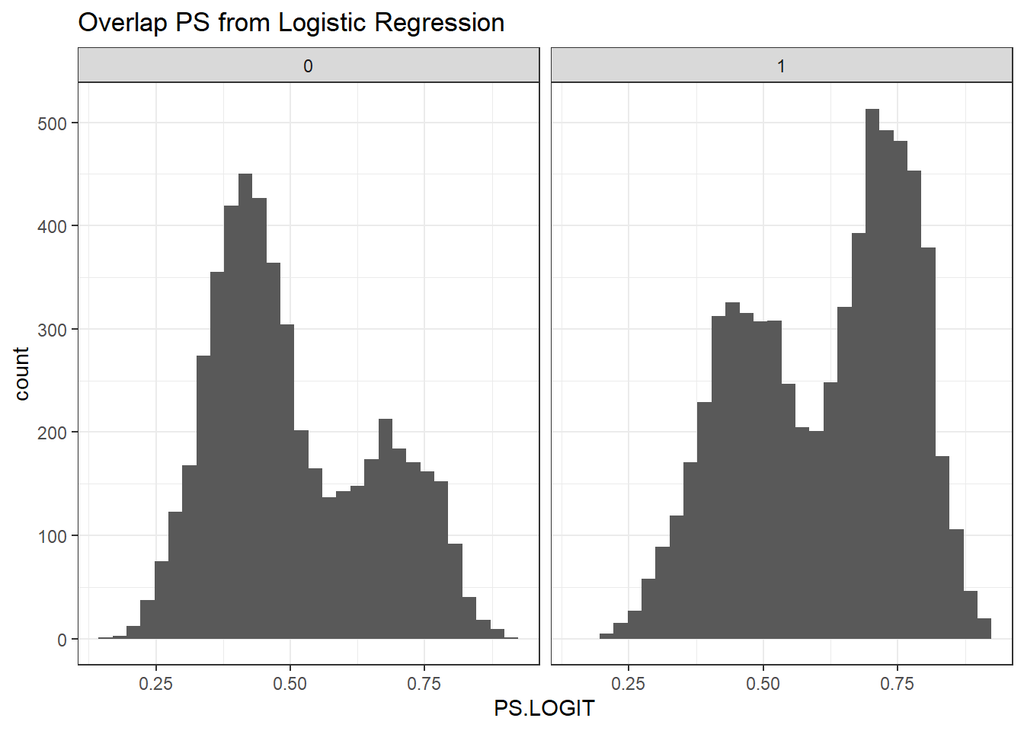

```r
ggplot(data=nmesdata, aes(x=PS.LOGIT))+geom_histogram()+facet_grid(~eversmk)+theme_bw()+ggtitle("Overlap PS from Logistic Regression")
```

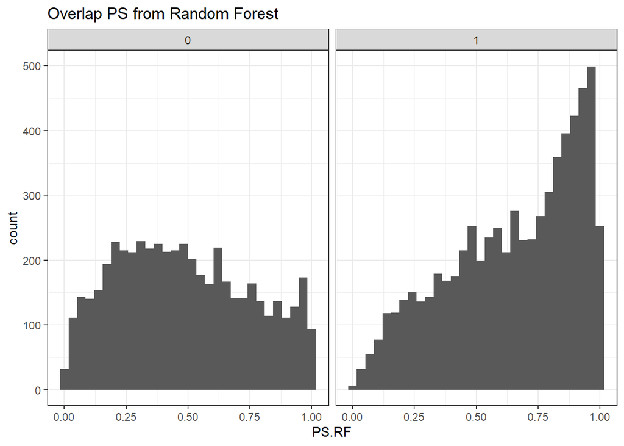

```r
ggplot(data=nmesdata, aes(x=PS.RF))+geom_histogram()+facet_grid(~eversmk)+theme_bw()+ggtitle("Overlap PS from Random Forest")
```

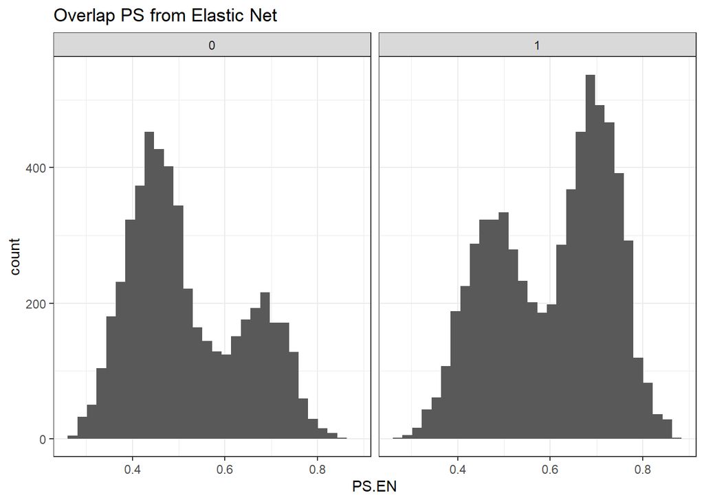

```r
ggplot(data=nmesdata, aes(x=PS.EN))+geom_histogram()+facet_grid(~eversmk)+theme_bw()+ggtitle("Overlap PS from Elastic Net")
```

The region where the histograms of both groups overlap is the common support.

### Step 5: Match by propensity score in 1:1 matching and compare covariate balance and population size

The matchit function matches individuals by “distance”. Here, we make our distance the propensity score. We matching to the *nearest* value that is within a *caliper* of 0.2 standard deviations. If there are observations, either exposed or unexposed, without any matches, they are *discarded* from the analysis. The *ratio* of exposed to unexposed in matching is 1.

```r
#Creating matching using propensity scores from logistic regression
  nn1 <- matchit(eversmk ~ LASTAGE + MALE + educate + beltuse + POVSTALB + marital + RACE3 + SREGION,
                    data=nmesdata, distance=nmesdata$PS.LOGIT, method="nearest", discard="both", caliper=0.2,
                    ratio=1)
  nn1.data <- match.data(nn1)
  summary(nn1, standardize=T)
```

```
##
## Call:
## matchit(formula = eversmk ~ LASTAGE + MALE + educate + beltuse +
##     POVSTALB + marital + RACE3 + SREGION, data = nmesdata, method = "nearest",
##     distance = nmesdata$PS.LOGIT, discard = "both", caliper = 0.2,
##     ratio = 1)
##
## Summary of Balance for All Data:
##           Means Treated Means Control Std. Mean Diff. Var. Ratio eCDF Mean
## distance         0.6132        0.5055          0.6945     1.0527    0.1891
## LASTAGE         59.0891       61.6876         -0.2134     0.7858    0.0474
## MALE0            0.4459        0.7227         -0.5568          .    0.2768
## MALE1            0.5541        0.2773          0.5568          .    0.2768
## educate1         0.1316        0.1545         -0.0676          .    0.0229
## educate2         0.1507        0.1328          0.0500          .    0.0179
## educate3         0.5178        0.4704          0.0948          .    0.0474
## educate4         0.1999        0.2423         -0.1060          .    0.0424
## beltuse1         0.2599        0.2146          0.1033          .    0.0453
## beltuse2         0.2153        0.1915          0.0578          .    0.0237
## beltuse3         0.5248        0.5939         -0.1382          .    0.0690
## POVSTALB1        0.1018        0.1139         -0.0401          .    0.0121
## POVSTALB2        0.0457        0.0577         -0.0576          .    0.0120
## POVSTALB3        0.1397        0.1457         -0.0174          .    0.0060
## POVSTALB4        0.3167        0.3068          0.0214          .    0.0099
## POVSTALB5        0.3961        0.3759          0.0414          .    0.0202
## marital1         0.6846        0.6235          0.1315          .    0.0611
## marital2         0.1371        0.2280         -0.2641          .    0.0908
## marital3         0.1076        0.0685          0.1261          .    0.0391
## marital4         0.0276        0.0219          0.0347          .    0.0057
## marital5         0.0431        0.0581         -0.0739          .    0.0150
## RACE31           0.0526        0.0753         -0.1017          .    0.0227
## RACE32           0.1495        0.1666         -0.0482          .    0.0172
## RACE33           0.7980        0.7581          0.0993          .    0.0399
## SREGION1         0.2113        0.1760          0.0865          .    0.0353
## SREGION2         0.2473        0.2491         -0.0042          .    0.0018
## SREGION3         0.3524        0.3892         -0.0771          .    0.0368
## SREGION4         0.1891        0.1857          0.0085          .    0.0033
##           eCDF Max
## distance    0.2997
## LASTAGE     0.0954
```

[output cut: 78 more lines]

```
## marital5    0.0023          0.4346
## RACE31      0.0023          0.4677
## RACE32      0.0044          0.7163
## RACE33      0.0021          0.7861
## SREGION1    0.0239          0.7827
## SREGION2    0.0064          0.8142
## SREGION3    0.0147          0.9182
## SREGION4    0.0028          0.7503
##
## Sample Sizes:
##           Control Treated
## All          5023    6564
## Matched      4350    4350
## Unmatched     667    2211
## Discarded       6       3
```

```r
#Creating matching using propensity scores from random forest
  nn1.rf <- matchit(eversmk ~ LASTAGE + MALE + educate + beltuse + POVSTALB + marital + RACE3 + SREGION,
                    data=nmesdata, distance=nmesdata$PS.RF, method="nearest", discard = "both", caliper=0.2,
                    ratio=1)
  nn1.data.rf <- match.data(nn1.rf)
  summary(nn1.rf, standardize=T)
```

```
##
## Call:
## matchit(formula = eversmk ~ LASTAGE + MALE + educate + beltuse +
##     POVSTALB + marital + RACE3 + SREGION, data = nmesdata, method = "nearest",
##     distance = nmesdata$PS.RF, discard = "both", caliper = 0.2,
##     ratio = 1)
##
## Summary of Balance for All Data:
##           Means Treated Means Control Std. Mean Diff. Var. Ratio eCDF Mean
## distance         0.6489        0.4843          0.6316     0.9478    0.1714
## LASTAGE         59.0891       61.6876         -0.2134     0.7858    0.0474
## MALE0            0.4459        0.7227         -0.5568          .    0.2768
## MALE1            0.5541        0.2773          0.5568          .    0.2768
## educate1         0.1316        0.1545         -0.0676          .    0.0229
## educate2         0.1507        0.1328          0.0500          .    0.0179
## educate3         0.5178        0.4704          0.0948          .    0.0474
## educate4         0.1999        0.2423         -0.1060          .    0.0424
## beltuse1         0.2599        0.2146          0.1033          .    0.0453
## beltuse2         0.2153        0.1915          0.0578          .    0.0237
## beltuse3         0.5248        0.5939         -0.1382          .    0.0690
## POVSTALB1        0.1018        0.1139         -0.0401          .    0.0121
## POVSTALB2        0.0457        0.0577         -0.0576          .    0.0120
## POVSTALB3        0.1397        0.1457         -0.0174          .    0.0060
## POVSTALB4        0.3167        0.3068          0.0214          .    0.0099
## POVSTALB5        0.3961        0.3759          0.0414          .    0.0202
## marital1         0.6846        0.6235          0.1315          .    0.0611
## marital2         0.1371        0.2280         -0.2641          .    0.0908
## marital3         0.1076        0.0685          0.1261          .    0.0391
## marital4         0.0276        0.0219          0.0347          .    0.0057
## marital5         0.0431        0.0581         -0.0739          .    0.0150
## RACE31           0.0526        0.0753         -0.1017          .    0.0227
## RACE32           0.1495        0.1666         -0.0482          .    0.0172
## RACE33           0.7980        0.7581          0.0993          .    0.0399
## SREGION1         0.2113        0.1760          0.0865          .    0.0353
## SREGION2         0.2473        0.2491         -0.0042          .    0.0018
## SREGION3         0.3524        0.3892         -0.0771          .    0.0368
## SREGION4         0.1891        0.1857          0.0085          .    0.0033
##           eCDF Max
## distance    0.2655
## LASTAGE     0.0954
```

[output cut: 78 more lines]

```
## marital5    0.0073          0.5255
## RACE31      0.0128          0.5526
## RACE32      0.0057          0.7624
## RACE33      0.0186          0.8983
## SREGION1    0.0214          0.7606
## SREGION2    0.0038          0.8396
## SREGION3    0.0265          0.9678
## SREGION4    0.0013          0.7845
##
## Sample Sizes:
##           Control Treated
## All          5023    6564
## Matched      4525    4525
## Unmatched     493    2039
## Discarded       5       0
```

```r
  #Creating matching using propensity scores from elastic net
  nn1.en <- matchit(eversmk ~ LASTAGE + MALE + educate + beltuse + POVSTALB + marital + RACE3 + SREGION,
                    data=nmesdata, distance=nmesdata$PS.EN, method="nearest", discard = "both", caliper=0.2,
                    ratio=1)
  nn1.data.en <- match.data(nn1.en)
  summary(nn1.en, standardize=T)
```

```
##
## Call:
## matchit(formula = eversmk ~ LASTAGE + MALE + educate + beltuse +
##     POVSTALB + marital + RACE3 + SREGION, data = nmesdata, method = "nearest",
##     distance = nmesdata$PS.EN, discard = "both", caliper = 0.2,
##     ratio = 1)
##
## Summary of Balance for All Data:
##           Means Treated Means Control Std. Mean Diff. Var. Ratio eCDF Mean
## distance         0.6040        0.5175          0.6879     1.0417    0.1858
## LASTAGE         59.0891       61.6876         -0.2134     0.7858    0.0474
## MALE0            0.4459        0.7227         -0.5568          .    0.2768
## MALE1            0.5541        0.2773          0.5568          .    0.2768
## educate1         0.1316        0.1545         -0.0676          .    0.0229
## educate2         0.1507        0.1328          0.0500          .    0.0179
## educate3         0.5178        0.4704          0.0948          .    0.0474
## educate4         0.1999        0.2423         -0.1060          .    0.0424
## beltuse1         0.2599        0.2146          0.1033          .    0.0453
## beltuse2         0.2153        0.1915          0.0578          .    0.0237
## beltuse3         0.5248        0.5939         -0.1382          .    0.0690
## POVSTALB1        0.1018        0.1139         -0.0401          .    0.0121
## POVSTALB2        0.0457        0.0577         -0.0576          .    0.0120
## POVSTALB3        0.1397        0.1457         -0.0174          .    0.0060
## POVSTALB4        0.3167        0.3068          0.0214          .    0.0099
## POVSTALB5        0.3961        0.3759          0.0414          .    0.0202
## marital1         0.6846        0.6235          0.1315          .    0.0611
## marital2         0.1371        0.2280         -0.2641          .    0.0908
## marital3         0.1076        0.0685          0.1261          .    0.0391
## marital4         0.0276        0.0219          0.0347          .    0.0057
## marital5         0.0431        0.0581         -0.0739          .    0.0150
## RACE31           0.0526        0.0753         -0.1017          .    0.0227
## RACE32           0.1495        0.1666         -0.0482          .    0.0172
## RACE33           0.7980        0.7581          0.0993          .    0.0399
## SREGION1         0.2113        0.1760          0.0865          .    0.0353
## SREGION2         0.2473        0.2491         -0.0042          .    0.0018
## SREGION3         0.3524        0.3892         -0.0771          .    0.0368
## SREGION4         0.1891        0.1857          0.0085          .    0.0033
##           eCDF Max
## distance    0.2934
## LASTAGE     0.0954
```

[output cut: 78 more lines]

```
## marital5    0.0030          0.4390
## RACE31      0.0097          0.4956
## RACE32      0.0136          0.7270
## RACE33      0.0039          0.8120
## SREGION1    0.0242          0.7783
## SREGION2    0.0136          0.8487
## SREGION3    0.0106          0.9434
## SREGION4    0.0000          0.2982
##
## Sample Sizes:
##           Control Treated
## All          5023    6564
## Matched      4340    4340
## Unmatched     679    2222
## Discarded       4       2
```

```r
  #More individuals "match" using RF propensity score than logistic regression

##Compare exchangeability across matched populations

  #Average Standardized Mean Difference-Unmatched
  mean(abs(summary(nn1, standardize=T)$sum.all[, 3][-1]))
```

```
## [1] 0.1177137
```

```r
    # Matching attempt #1 Logistic Regression Propensity Score
    mean(abs(summary(nn1, standardize=T)$sum.matched[, 3][-1]))
```

```
## [1] 0.03219356
```

```r
    # Matching attempt #2 Random Forest Propensity Score
    mean(abs(summary(nn1.rf, standardize=T)$sum.matched[, 3][-1]))
```

```
## [1] 0.06000446
```

```r
    # Matching attempt #3 Elastic Net Propensity Score
    mean(abs(summary(nn1.en, standardize=T)$sum.matched[, 3][-1]))
```

```
## [1] 0.03961405
```

### Estimate and compare effects across algorithms

```r
 outcome.model.1 <- glm(lc5 ~ eversmk, data=nn1.data, family=binomial(link="logit"))

    exp(outcome.model.1$coefficients)
```

```
## (Intercept)    eversmk1
## 0.004386978 6.079313814
```

```r
        exp(confint(outcome.model.1))
```

```
##                   2.5 %       97.5 %
## (Intercept) 0.002695883  0.006672937
## eversmk1    3.827702999 10.211477865
```

```r
 outcome.model.2 <- glm(lc5 ~ eversmk, data=nn1.data.rf, family=binomial(link="logit"))

        exp(outcome.model.2$coefficients)
```

```
## (Intercept)    eversmk1
## 0.004662522 5.792706915
```

```r
            exp(confint(outcome.model.2))
```

```
##                   2.5 %      97.5 %
## (Intercept) 0.002939295 0.006958231
## eversmk1    3.719039182 9.486140714
```

```r
 outcome.model.3 <- glm(lc5 ~ eversmk, data=nn1.data.en, family=binomial(link="logit"))

        exp(outcome.model.3$coefficients)
```

```
## (Intercept)    eversmk1
## 0.004164739 6.769301640
```

```r
            exp(confint(outcome.model.3))
```

```
##                   2.5 %       97.5 %
## (Intercept) 0.002522713  0.006402512
## eversmk1    4.229467270 11.508223288
```